# OpenStreetMap Project

**Map Area: Beijing, China**

I obtained the OSM XML data of Beijing, China from [Map Zen](https://mapzen.com/data/metro-extracts/). Beijng is my hometown and I am interested to know how complete the dataset is for this area and how it can be improved in future. Besides, As Beijing is my hometown, According to the OpenStreetMap wiki, the local language is used in the nameLocalization issue.

## 1. Problems Encountered in the Map

### 1.1. Language

In the OSM XML document, Chinese are used in both key and value attributes as well as English. At first, I considered using Google translate to translate everything into English for uniformity and consistency. However, after testing a few words and phrases in Google translate, I gave up on the idea as some results are not correct. Therefore, after checking MongoDB's documentation and confirmed that simplified and traditional Chinese are all supported, I decided to keep the document billingual.

Still, I believe it is worthwhile to translate all the keys in the key string to English so that we can manipulate the data easier in the MongoDB. So I audited the key to locate the key with Chinese character in it and manually translated them into their English meanings or use other suitable keys that follow the OSM guideline.

```
    <tag k="应急避难场所" v="yes"/>            <---   <tag k= "social_facility" v= "emergency shelter"/>
    <tag k="应急避难人数（万人）" v="3.57"/>    <---   <tag k= "capacity" v= "35,700"/>
    <tag k="建成时间" v="2006"/>              <---   <tag k= "build_date" v="2006"/>

    <tag k="黄南苑小区" v="bus_station"/>      <---  <tag k= "name" v="黄南苑小区"/>
                                                    <tag k = "amenity" v= "bus_station"/>
```

### 1.2. Problematic Characters in Key attributes

As '.' and SPACE is not allowed to use as keys in MongoDB, I checked for the problematic characters in the XML file and listed them. And my result is:

> {'problemchars': 5, 'lower': 290612, 'other': 921, 'lower_colon': 16735} ['No.', 'emergency shelter', 'emergency shelter', 'emergency shelter', 'emergency shelter']

I located the first problematic character in `<tag k="No." v="985,852,974"/>` which is a bus stop. I identified the value for this entry to be the bus routes that pass this stop, and after reading the wiki page on bus_stop, I decided to remove this entry as the information should be associated with the corresponding route=* relationbus route instead.

For the 'emergency shelter', I found entries similar to this one:

```
<tag k="name" v="奥林匹克森林公园"/>
<tag k="leisure" v="park"/>
<tag k="name:en" v="Olympic Forest Park"/>
<tag k="emergency" v="yes"/>
<tag k="emergency shelter" v="park"/>
<tag k="应急避难场所" v="是"/>
<tag k="疏散人数(万人)" v="2"/>
```

They are all facilitys' that can be used as emergency shelter/area when disaster happens. According to [Social Facility](http://wiki.openstreetmap.org/wiki/Key:social_facility) page that the model which specify this type of temporary shelter for disaster relief is still under development. Therefore, I decided to use the more common key 'social_facility' in this situation. `<tag k="social_facility" v="emergency shelter"/>`

After shorten the XML OSM file, I also printed out the list of key words with other charecters than lowercase letter and colon but have no SPACE and '.'. Eventhough those keys can all be used in MongoDB, I have changed some of them improve data uniformity. For example:

- "FIXME" -> 'fixme'
- 'name_1' -> 'alt_name' or 'name:en'
- 'bridge:name:en' -> 'name:en'
- 'amenity_1' -> 'amenity'
- 'attribute', 'attribute_1', 'attribute2', etc. -> 'social_facility'

### 1.3. Key: name

As expected, there are different keys for names in the XML file, the most common one is `k = "name"`, and there are also name keys in different langurages like `k="name:en"`, `k="name:zh"`, and `k="name:zh_pinyin"`. In addition, there are also use of `k="int_name"` and `k= "alt_name"`.

I learnt from the OpenStreetMap wiki, we should use the local language in the name tag and then label use `name:en`,`name:zh` keys for the alternative names. One correct example is as follows:

```
<tag k="name" v="梨园北街"/>
<tag k="highway" v="tertiary"/>
<tag k="name:en" v="Liyuan North Street"/>
<tag k="name:zh" v="梨园北街"/>
<tag k="name:zh_pinyin" v="líyuán běi jiè"/>
```

According to the [Key: name](http://wiki.openstreetmap.org/wiki/Key:name) page, it is recommended to use language specific names, e.g. name:en= instead of int_name, therefore, I mapped all the `"int_name" -> "name:en"`.

Besides, "alt_name" are designed "alternative name by which the feature is known", but it is misused by some contributers of the OSM for language names in other languages.

Another problem is that users put alternative names or name in different language in a bracket. For example:

```
<tag k="name" v="九龙壁 (Nine Dragon Screen)"/>
<tag k="name:en" v="Shi Fang (Marble Boat)"/>
<tag k="name" v="Yi Pen Shui (A Basin of Water)"/>
<tag k="name" v="IBM中国软件开发中心(得实大厦)"/>
```

However, in some cases they are the correct name. For example, a college with different campus.

```
<tag k="alt_name" v="北京建筑工程学院(展览馆路校区)"/>
```

Therefore, it is going to require manual labour to fix this problem line by line.

In addition, some contributor did not follow the guideline to use the local name for the value of `k="name"`. For example:

```
<tag k="name" v="Тренинг-центр Китайского Красного Креста"/>
<tag k="name_1" v="Training Centre. Red Cross of China"/>
<tag k="name:en" v="Training Centre. Red Cross of China"/>
```

The last problem of the key:name is misuse. In the following case, user used name key but according to the value s/he provide, this should belong to "key:sport", "key:leisure", and "key:landuse"

wrong:

```
<tag k="name" v="操场"/>
<tag k="name_1" v="足球场"/>
<tag k="name_2" v="田径场"/>
<tag k="name_3" v="排球场"/>
```

correct:

```
<tag k="sport" v="volleyball"/>
<tag k="sport" v="soccer"/>
<tag k="leisure" v="track"/>
<tag k="landuse" v="recreation_ground"/>
```

And this is another problem that need to be fixed manually.

### 1.4. Key:addr:street & Key:addr:housenumber

#### 1.4.1. Mixed use of Chinese, English and Pinyin

**Pinyin** is the official romanization system for Standard Chinese in mainland China. It is the direct mappying from the pheonic sound to the romanic character.

When auditing the street names, I found many anomalies. Most of the problems are caused by using pinyin or chinese to represent street names. As I cannot translate all the name to chinese, as recommended by the guideline, I decide to leave the name as it is, which we can also change in the database.

Some examples:

```
<tag k="addr:street" v="Guozijian Dajie"/>       <- Pinyin
<tag k="addr:street" v="Gongti Beilu"/>
<tag k="addr:street" v="Beisanlitun Nan"/>
<tag k="addr:street" v="东城区安定门外大街青年湖北北街"/>        <- Chinese
<tag k="addr:street" v="朝阳门内大街 (Chaoyangmne Nei Dajie)"/>    <- Combined
```

The similar problem exist in the housenumber as well.

```
<tag k="addr:housenumber" v="118a"/>
<tag k="addr:housenumber" v="9"/>
tag k="addr:housenumber" v="甲1"/>
```

I considered using Google Translate API to translate all the data to Chinese, however, as there are different tones in Chinese, the Google Translate cannot gurantee a correct translation.

#### 1.4.2. Street Number and Street Name

When I printed out the anomalies in the street address, I see some sets with 'u53f7' in the ending part of the keys.

> ```
> u'11\u53f7': set([u'\u5317\u4eac\u5e02\u671d\u9633\u533a\u5317\u4e09\u73af\u4e1c\u8def11\u53f7']),
>  u'125\u53f7': set([u'\u671d\u5185\u5317\u5c0f\u8857\u7532125\u53f7']),
>  u'133-2\u53f7': set([u'\u671d\u9633\u95e8\u5185\u5927\u8857133-2\u53f7']),
>  u'16\u53f7': set([u'\u5efa\u5916\u5927\u8857\u6c38\u5b89\u91cc\u753216\u53f7']),
>  u'25\u53f7':
> ```

I quickly realized the it is the unicode presentation for the chinsese character in hex value, therefore I looked up the value `u53f7`, i.e. the unicode `&#21495`, which is the chinese character "号". This character means number in English.

The problem here is users have put the street number and street address as the value for the `key:addr:street`, which value should be the street name only.

As there are mostly apartment building in China, I also noticed some entrie where people put street name and housenumber in addr:street and then the apartment number in teh addr:housename.

On the other hand, there are also cases where user put street name and street number as the value to the `key:addr:housenumber`, i.e. `<tag k="addr:housenumber" v="汤立路201号院"/>`

Unfortunately, this is yet another problem that need to be cleaned manually.

#### 1.4.3. Other Key:addr Problems

- Unexpected valid street names(i.e."Alley", "Hutong")
- The district names in the street names(i.e. "Gong Ti Bei Lu, Chaoyang District" -> "Gong Ti Bei Lu" ).
- Strange Translation (i.e."Dong3Huan" -> "北三环")
- No street type (i.e. 'Xuan Wu Men' -> "Xuan Wu Men Street')
- Wrong Data (i.e. "Huaqing Jia Yuan" -> delete the tag and create another tag to store the data)

### 1.5 Different Format in Phone number and Capacity

#### 1.5.1. Phone number

Phone number in the file are recored in different way. Some of them have area code and international code, some does not, and the prefix are also in different formatted in different manner and some even have mistake in it. For example:

> '+86-10-60712288' '861064057111' '+86 1360 1135725' '+86 10 63016688' '62555813' '01064185590' '+86-010-67814533' '(8610)13717888828' '+86(010)62591264'

I reformat the phone number to be:

> '+86-10-60712288' <- for landline  
> '+86-13601135725' <- for mobile phone

Code:

```
`def clean_phone(number):
    """Clean/reformat the phone value."""
    numberlist = re.findall("\d",number)
    new_number = "".join(numberlist)
    if len(new_number) == 8:
        new_number = "010" + new_number
    new_number = new_number[-11:]
    if new_number.startswith('1'):
        new_number = "+86-" + new_number
    else:
        new_number = "+86-10-" + new_number[-8:]
    return new_number`
```

#### 1.5.2. Capacity

Capacity of a place are also recorded by users in variaty of ways. For example:

> '3.5', '13,700 people', '14352 people', '80000'

The reason why there is float in the data is that some users input the data in different scale, the number should be multiplied by 10000 to be consistent with others. Besides, the character and ',' in the value also need to be removed.  
I reformatted the data to only keep the number with correct scale.

Code:

```
`def clean_capacity(capacity):
    """Correct and returned the capacity data with uniform format."""
    if not re.search('\d', capacity):
        return capacity
    cap = re.findall(r'[-+]?\d*\.\d+|\d+',capacity)
    new_c = "".join(cap)
    if "." in new_c:
        new_c = 10000 * float(new_c)
    return int(new_c)`
```

### 1.6. Overall

#### 1.6.1. Validity and Accuracy

Even though it is out of the scope of this project to validate all the data obtained from the OpenStreetMap and locate all the mistakes, I was able to discover many problems relating to the validity and accuracy of the data from simple auditing for the data format and content. For example, by auditing the postcode, I quickly discovered that one phone number is misused as a postcode. More examples as follows, using district name as street name and postcode as housenumber.

```
    <tag k="addr:street" v="Chao Yang"/>
    <tag k="addr:housenumber" v="100600"/>
```

And there are also error like `<tag k="phone" v="03126550752"/>` where the value is likely to be "13126550752" according to the chinese phone number format.

#### 1.6.2. Completeness

The map data of Beijing I obtained is far from complete. There are many places that I know in Beijing, including my home haven't been added to the document yet. And for the existing nodes and ways, may of them lack information, for example, the proper Chinese name, the use of the facility, and so on.

#### 1.6.3. Consistency and Uniformity

The data consistency and Uniformity is a disaster. First, there is the language problem. Second, as it is a opensource project, users create their own tags and use different keys to label the same thing. Third, the same type of key value are formatted in different ways. Aside from the problems mentioned above, I also found people using different language or words to indicate the same thing, for example, people use several ways to say "emergency shelters" in chinese and english, I converted all of them to "应急避难场所“.

### 2. Data Overview

#### File Sizes

- beijing_china.osm: 152.4 MB
- beijing_china.json: 171.3 MB

#### Number of documents

`> db.maps.count()`

> 806243

#### Number of nodes

`> db.maps.find({type: "node"}).count()`

> 705066

#### Number of ways

`> db.maps.find({type: "way"}).count()`

> 101169

#### Number of unique users

`> db.maps.distinct("created.user").length`

> 1305

#### Top 10 contributing users

`> db.maps.aggregate([{"$group": {"_id": "$created.user","count": {"$sum": 1}}}, {"$sort": {"count": - 1}}, {"$limit": 10}]);`

> { "_id" : "Chen Jia", "count" : 170368 } { "_id" : "R438", "count" : 160832 } { "*id" : "ij*", "count" : 52291 } { "_id" : "hanchao", "count" : 47690 } { "_id" : "katpatuka", "count" : 25319 } { "_id" : "m17design", "count" : 22094 } { "_id" : "Esperanza36", "count" : 19571 } { "_id" : "nuklearerWintersturm", "count" : 17959 } { "_id" : "RationalTangle", "count" : 14563 } { "_id" : "u_kubota", "count" : 8344 }

```python
%pylab inline
import pandas as pd
import numpy as np
from pymongo import MongoClient
import matplotlib.pyplot as plt
```

```python
# Plot the user contribution distribution
client = MongoClient('localhost:27017')
db = client.beijing

c = db.maps.aggregate([{"$group": {"_id": "$created.user","count": {"$sum": 1}}},
                       {"$sort": {"count": - 1}}])
df = pd.DataFrame(list(c))
```

```python
df.columns = ["Users", "Entries"]
print df.head()
print df.describe()
```

```
       Users  Entries
0   Chen Jia   169727
1       R438   152653
2        ij_    52158
3    hanchao    47645
4  katpatuka    24937
             Entries
count    1305.000000
mean      600.557854
std      6758.155411
min         1.000000
25%         2.000000
50%        10.000000
75%        49.000000
max    169727.000000
```

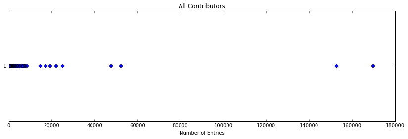

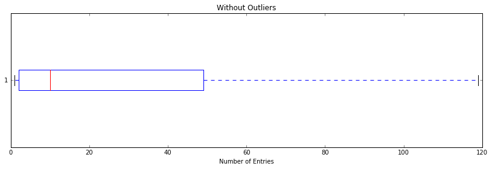

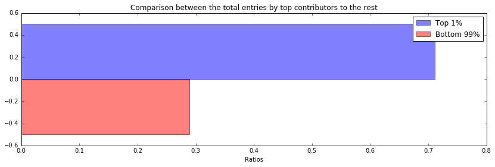

```python
plt.figure(figsize = (14,4))
plt.boxplot(df.Entries, 0, 'gD', 0, patch_artist=True)
plt.xlabel("Number of Entries")
plt.title("All Contributors")
plt.show()

plt.figure(figsize = (14,4))
plt.boxplot(df.Entries, 0, '',0)
plt.xlabel("Number of Entries")
plt.title("Without Outliers")
plt.show()

top_one_percentage = df.Entries.quantile(.99)
top_contributors = df[df.Entries >= top_one_percentage]
other_contributors = df[df.Entries < top_one_percentage]

plt.figure(figsize = (14,4))
index = np.arange(1)
bar_width = 0.5
opacity = 0.5
top_sum_ratio = float(top_contributors.Entries.sum())/df.Entries.sum()
other_sum_ratio = float(other_contributors.Entries.sum())/df.Entries.sum()

rects1 = plt.barh(index, top_sum_ratio, bar_width,
                 alpha=opacity,
                 color='b',
                 label='Top 1%')

rects2 = plt.barh(index - bar_width, other_sum_ratio, bar_width,
                 alpha=opacity,
                 color='r',
                 label='Bottom 99%')
plt.xlabel('Ratios')
plt.legend()

plt.title("Comparison between the total entries by top contributors to the rest")
plt.show()


# We can see visually that the top one percent of contributors contributed to about 70% of all the entries.
```

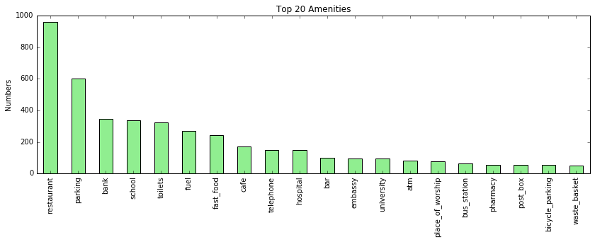

```python
c4 = db.maps.aggregate([{"$match": {"amenity": {"$exists": 1}}},
                        {"$group": {"_id": "$amenity","count": {"$sum": 1}}},
                        {"$sort": {"count": - 1}}, {"$limit": 20}])
df4 = pd.DataFrame(list(c4))
df4.columns = ["Place", "Numbers"]
plt.figure(figsize = (14,4))
fig = df4.Numbers.plot(kind = "bar", color = "lightgreen")
fig.set_title("Top 20 Amenities")
fig.set_ylabel("Numbers")
fig.set_xticklabels(df4.Place)
plt.show()

# A lot of places for food!
```

### 3. Additional Ideas

#### 3.1. Emergency Shelter Locator

When audit the data, I fixed some entries about the emergency shelters that can be used when a disaster, for example, an earthquake happend. The typical entry has information about its location and its capacity. I believe this infomation can be utilised to make an emergency shelter. A usecase can be when disaster strikes, the shelter locator can tell you the nearest shelter you can go to that have enough capacity. Here, I will simply clean the data and print out a form with name, location, and capacity of the shelters.

```python
# Though there are difference in the naming method, they all mean the same thing, "emergency shelter"("应急避难场所“)
# As there are no other value for the social_facility key, It is quite convenient that we can update the value to
# a uniform name easily.

# I have already cleaned the data of the social_faicility name and capacity.

query = {"social_facility": {"$exists": 1}}
projection = {"_id":0, "name":1, "capacity": 2, "pos":3, "social_facility":4}
c2 = db.maps.find(query,projection)
df2 = pd.DataFrame(list(c2))

df2.head(10)
```

|  | capacity | name | pos | social_facility |
| --- | --- | --- | --- | --- |
| 0 | NaN | 北方企业集团马池口村 | [40.1815426, 116.2156364] | 应急避难场所 |
| 1 | 14352.0 | 兴城广场 | [39.7532186, 116.3349794] | 应急避难场所 |
| 2 | NaN | 太阳宫公园 | NaN | 应急避难场所 |
| 3 | 20000.0 | 奥林匹克森林公园 | NaN | 应急避难场所 |
| 4 | NaN | 阳光星期八公园 | NaN | 应急避难场所 |
| 5 | 18382.0 | 亢山广场 | NaN | 应急避难场所 |
| 6 | 72800.0 | 兴隆公园 | NaN | 应急避难场所 |
| 7 | NaN | 昌平公园 | NaN | 应急避难场所 |
| 8 | 24300.0 | 回龙观体育中心 | NaN | 应急避难场所 |
| 9 | 28000.0 | 回龙园 | NaN | 应急避难场所 |

#### 3.2. In History

This idea is related to the OpenStreetMap project, I believe a history layer can be added to the map so that people can go back in time to see what it was like in the past. It would be great for city like Beijing, which has a long history. In order to achieve that purpose, I believe some addititional key need to be added, for example, the date when the building and road is built, and the date when it close down or changed.

#### 3.3. A Cultural Perspective

I think it going to be interesting doing a cross analysis of different regions in terms of the top amenities. It can potentially shed light on what local people (or in some cases, the expat OSM contributers) care about the most.

### 4. Conclusion

Through interacting with the dataset and reading the documentation, I have not only gained insight into the data wrangling process, but also discovered many interesting aspects of OpenStreetMap project. And I am very excited about the potential use of the data. In this project, I have used a mixed of manual and programmatical way to clean the data. As expected, the biggest problems that I encountered in wrangling the Beijing Map data is related to **Localization**. The problems are not only in language but also related to the culture, for example, people may have different way to categorize data and may use a different set of "convension" in storing and accessing information.

### 5. Reference

OpenStreetMap

- https://en.wikipedia.org/wiki/World_Geodetic_System#WGS84
- https://wiki.openstreetmap.org/wiki/Elements
- https://wiki.openstreetmap.org/wiki/Map_Features

Coding

- https://docs.python.org/2/library/xml.etree.elementtree.html
- https://docs.python.org/2/library/re.html
- https://www.w3.org/2001/XMLSchema

Language

- http://stackoverflow.com/questions/4813086/how-to-convert-chinese-characters-to-pinyin
- http://www.chinese-tools.com/tools/converter-unichar.html
- http://www.binaryhexconverter.com/hex-to-decimal-converter
- http://stackoverflow.com/questions/16027450/is-there-a-way-to-know-whether-a-unicode-string-contains-any-chinese-japanese-ch/16028174#16028174
- http://stackoverflow.com/questions/7948789/mongodb-mongod-complains-that-there-is-no-data-db-folder

Others

- https://ipython.org/ipython-doc/3/notebook/nbconvert.html